# R package

Luis Mario Trevisi

2020-11-18

# Introduction

Congratulations for getting this far. To complete the evidence that you have made a working R package please answer the following by using the supplied rmd and upload the knitted html to CANVAS.

I will assume your package is called **MYPAC** and you have packaged and documented functions `myf1`, `myf2`, `myf3` and `myf4`.

Your actual package name and functions will obviously be called something else.

# First function

Please place your first function in the r chunk in the following way:

Once you are ready please remove the option `eval = FALSE`

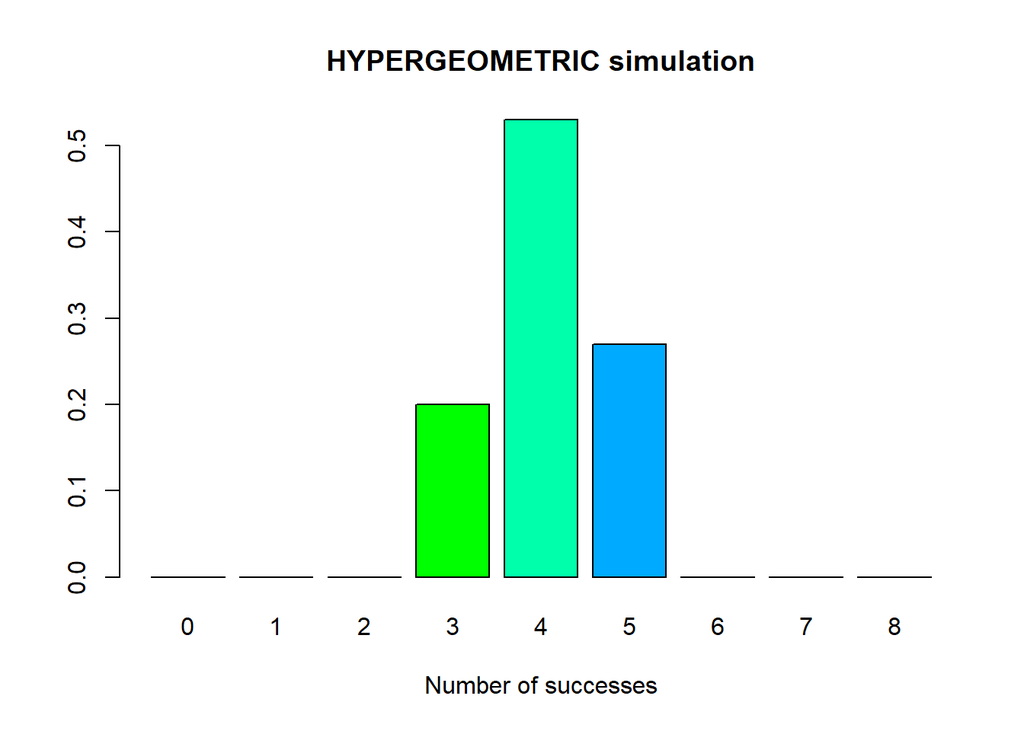

```
##
##    0    1    2    3    4    5    6    7    8
## 0.00 0.00 0.00 0.20 0.53 0.27 0.00 0.00 0.00
```

```r
MATH4753ouTrev0002::myhyper(100,10,5,8)
```

# Second function

Please place your second function in the r chunk in the following way:

Once you are ready please remove the option `eval = FALSE`

```r
MATH4753ouTrev0002::myci(x=rnorm(7,mean=3,sd=1),conf.int=0.95)
```

```
## [1] 2.861634 4.258729
```

# Third function

Please place your third function in the r chunk in the following way:

Once you are ready please remove the option `eval = FALSE`

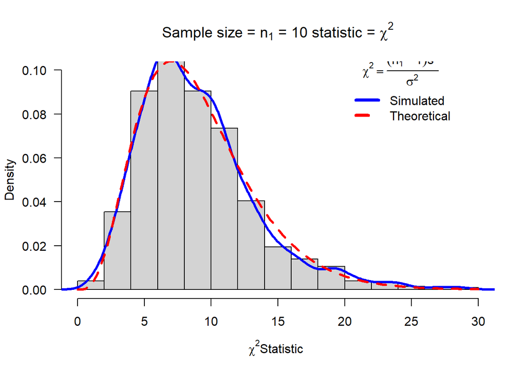

```r
MATH4753ouTrev0002::mychisim(n1 = 10, sigma1 = 3, mean1 = 5,iter = 1000,ymax = 0.1, x = 20, y = 0.1)
```

# Forth function

Please place your forth function in the r chunk in the following way:

Once you are ready please remove the option `eval = FALSE`

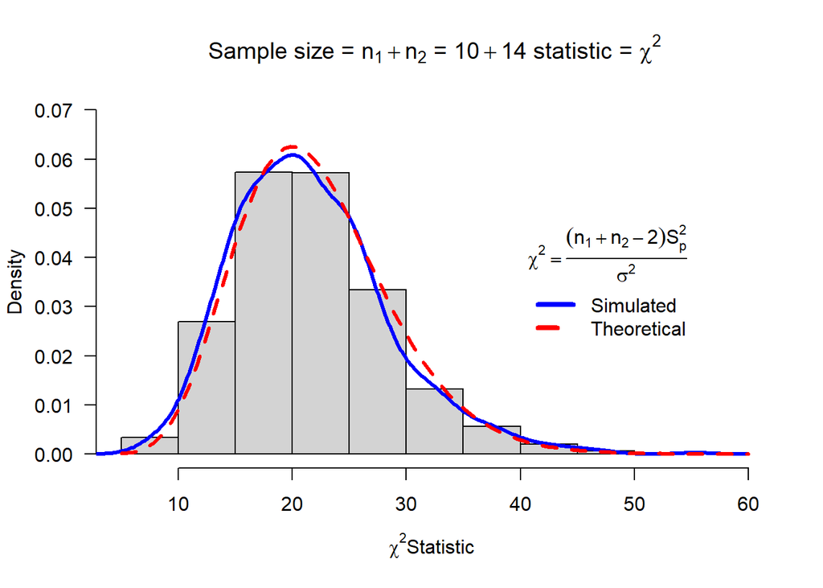

```r
MATH4753ouTrev0002::mychisim2(n1 = 10, n2 = 14, sigma1 = 3, sigma2 = 3, mean1 = 5,mean2 = 10, iter = 1000,ymax = 0.07,x = 40, y = 0.04,)
```

# The github repository

This is the address of my GITHUB repository: https://github.com/lmtrevisi/MATH4753ouTrev0002